# Arbeidskrav 2

## 1. Innledning

Hva ulike personer tjener og hvilke yrker som tjener mest er noe vi kan lese om hver eneste dag. I denne oppgaven skal vi se om hvordan høyde påvirker lønnen, og vi skal se på om det også er andre variabler som påvirker lønnen. Er det slik at desto høyere man er desto mer får en i lønn, eller er det slik at sivilstatus, utdanning og kjønn også påvirker lønnen?

## 2. Litteraturgjennomgang

For å kartlegge årsak til lønnsforskjeller mellom høye og mindre høye arbeidstakere, har forskerne sett på de kognitive, de ikke kognitive, de sosiale egenskaper, samt familieforhold og muskelstyrke.

Kognitive egenskaper oppfatter mentale funksjoner som sansing, oppmerksomhet, hukommelse og logiske evner (Malt (2019)). Ikke kognitive egenskaper refererer til personlige egenskaper som viljestyrke, utholdenhet, karisma og lederegenskaper. Foreldrenes sosioøkonomiske egenskaper (inntekt, skolegang) samt familieforholdet (genetikk, verdier og normer) ble også vurdert som mulige årsak til ulikheter (Lundborg, Nystedt, og Rooth (2014)). Deltagelse i friidrett, skoleklubber og dating hører til sosiale aktiviteter (Cinnirella og Winter (2009)).

Case og Paxson (2006) publiserte artikkel om forskning på forhold mellom høyde, evner og arbeidsmarked. Deres funn, for både kvinner og menn, er at en høyde økning på ca 10 cm kan gi en lønnsforskjell på hele 10 %. Deres estimater viser også at sannsynlighet for at en mann med høyde på ca 188 cm har 5 % større mulighet for å utøve en ledende stilling, enn en mann på ca 178 ca høyde. De påstår at det er en positiv korrelasjon mellom høyde og kognitive emner, som peker på at høyere mennesker er mer intelligente. Positiv korrelasjon mellom høyde og kognitive evner forklarer fenomenet at høyere mennesker får høyere lønn. Denne korrelasjonen er, etter (Case og Paxson (2006)), tydelig tidlig i livet og forblir gjennom. Fenomenet om at høyere mennesker velges inn i jobber som krever høyere nivå av intelligens og lavere nivå av fysiske ferdigheter forklares også med det positive samsvaret. Søkelys på høydefenomenet, til og med i vestlige land hvor arbeidsoppgaver ikke er preget av krevende fysisk arbeid, viser til sosial stigmatisering mot arbeidstakere med lavere høyde. Dette fenomenet åpner muligheter for videre forskning (Case og Paxson (2006)).

“Size Matters!”, sier Cinnirella og Winter (2009) i sitt arbeid om kroppshøyde og diskriminering i arbeidsmarkedet. De foretok en forskning på fenomenet høyde vs yrkes sortering av ansatte. Forskningen ble utført som et tverrsnitt over 13 europeiske land, og ga bevis til fordel for diskrimineringshypotesen. De har foretatt komparativ forskning over to like grupper, hvor en gruppe presenterer arbeidstakere, mens andre gruppe er dannet av selvstendig næringsdrivende. Gruppe med selvstendig næringsdrivende ikke er underordnet en arbeidsgiver. Begge grupper ble kontrollert for kognitive evner. Funnet av forskningen tydet på at høyde spiller en viktig rolle ved ansettelse av arbeidstakere, men spiller ingen rolle hos selvstendig næringsdrivende. Dette viser at arbeidsgiver er påvirket av de observerbare egenskaper hos en ansatte, og med dette bidrar til arbeidsdiskriminering av ansatte med lavere høyde. Cinnirella og Winter (2009) foreslår forklaring av høydefenomenet som:

- Arbeidsgiverens preferanse, hvor høyere ansatte prioriteres, uansett kognitive / ikke kognitive egenskaper
- Arbeidstakere med lavere kroppshøyde søker ikke på jobber som krever høyere intellektuelle ferdigheter
- Arbeidstakere med lavere kroppshøyde blir yrkesdiskriminert fra starten av sin karriere, og dette reflekteres på deres karriereutvikling.

Cinnirella og Winter (2009) konkluderer at det er stor sannsynlighet at arbeidstakere med lavere kroppshøyde ikke kommer til å ha en ledende stilling, uavhengig av deres utdanning, kognitive og ikke kognitive evner.

Forskerne Schick og Steckel (2015) har, også, sett på sammenheng mellom høyde, inntjening og ansattes ressurser. De har analysert data fra National Childhood Development Study, og kommet til konklusjon at høyere barn har bedre kognitive og ikke kognitive evner enn lavere barn. De har, også, påvist at hver av egenskapene står likt presentert og nødvendig for at vekst i høyden skal forutsette høydebelønning.

Lundborg, Nystedt, og Rooth (2014) diskuterer, i sin artikkel “Height and Earnings: The Role of Cognitive and Noncognitive Skills” om kan muskelmasse ses som en av de avgjørende faktorer for at høyere mennesker er bedre betalte. I den graden høyde og sportsaktiviteter utgjør en fordel i arbeidsmarkedskarakteristika kan muskelmasse bli en formidlende faktor mellom høyde og inntekter. Forskerne også viser at muskelmasse kan rangeres som en ikke-kognitiv faktor, og at de kan signalisere noe personlige trekk, som dominans og aggresjon. Muskelmasse kan også ses på som genetisk faktor som er korrelert med høyde og med dette gir positiv samvariasjon. Arbeidsoppgaver i dagens vestlige land er mer prosesserte og krever sjelden stor muskelstyrke. Derfor forutsettes at betydning av muskelmasse i en jobbkarakteristika sammenheng har avtatt med samfunnsutvikling (Lundborg, Nystedt, og Rooth (2014)).

Hvordan blir, alt dette, reflektert i praksis? I artikkelen “Height, Income, and Inequality” nevner «Height, Income, and Inequality | Iris» (u.å.) at hver tomme av høyden betyr $ 789 per år (tall fra USA) og at 90 % av CEO er over gjennomsnitt høye.

Her har vi lagt frem en bit av forskningslitteratur på «høydefenomenet». Det er mange elementer som samspiller i valget av ansatte. Gir vi, uten en fast forklaring, mulighet til høyere mennesker for å utvikle seg, mens de mindre høye ble sosial stigmatisert? Fra gammelt av daterer oppfatning om at de høge mennesker er beskyttere, ledere og trygghetsgivere. Kan vi, med «den gamle oppfatningen» forsvare datidens vekstdiskriminering? Eller er det på tide å vokse opp?

## 3. Analyse

### 3.1 Oppsummerende statistikk

[output not shown]

|  | marital | sex | education | afqt | heightInt |
| --- | --- | --- | --- | --- | --- |
|  | single :1124 | male :3402 | Min. : 1.00 | Min. : 0.00 | (64,68]:2298 |
|  | married :3806 | female:3604 | 1st Qu.:12.00 | 1st Qu.: 15.12 | (68,72]:1957 |
|  | separated: 366 | NA | Median :12.00 | Median : 36.76 | (60,64]:1778 |
|  | divorced :1549 | NA | Mean :13.22 | Mean : 41.21 | (72,76]: 628 |
|  | widowed : 161 | NA | 3rd Qu.:15.00 | 3rd Qu.: 65.24 | (56,60]: 285 |
|  | NA | NA | Max. :20.00 | Max. :100.00 | (76,80]: 48 |
|  | NA | NA | NA’s :10 | NA’s :262 | (Other): 12 |

Denne summary funksjonen gir oss en oppsummering av undersøkelsen. Hvor det blir forklart hvor mange deltakere det er totalt i datasettet, hvilket kjønn, hvilken sivilstatus de har, utdannelse, hvilken score de fikk på “Armed Forces Qualification Test”, og høyde.

Verdiene som kommer opp i summary forklarer oss forskjellige aspekter av undersøkelsen. Forklaring av de måleenhetene, brukt i summary: “1st qu”= første kvartil, “3rd qu”= tredje kvartil, Median= median av den utvalgte variabelen, Mean = gjennomsnitt av variabelen, Min & Max = minste og maks verdi av en variabel. NA = Not available

### 3.2 En variabel analyse

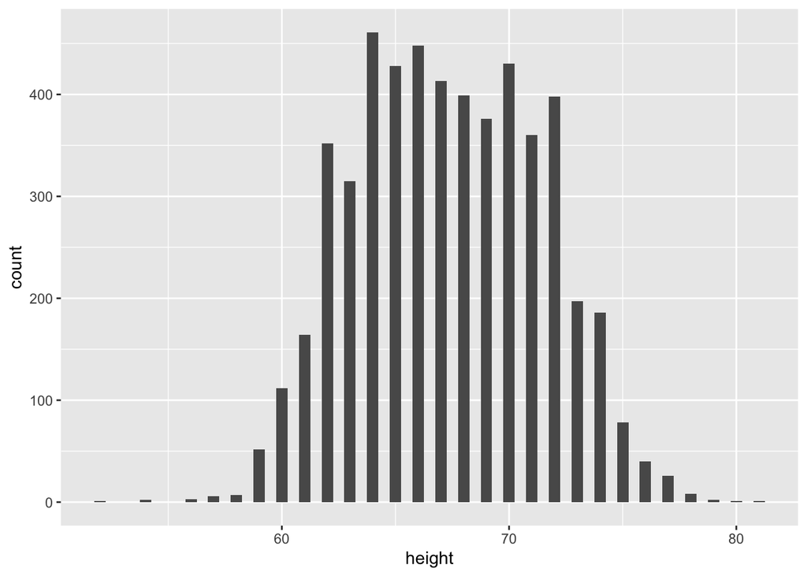

Histogrammet bekrefter antagelsen vår om høyden er normalfordelt. Det tyder på at datasettet er jevnt fordelt med tanke på deltakerne som er involvert. Det ser ut som et tilfeldig utvalg av individer er plukket ut til undersøkelsen, og at vi på bakgrunn av det ikke får noen tydelig bias.

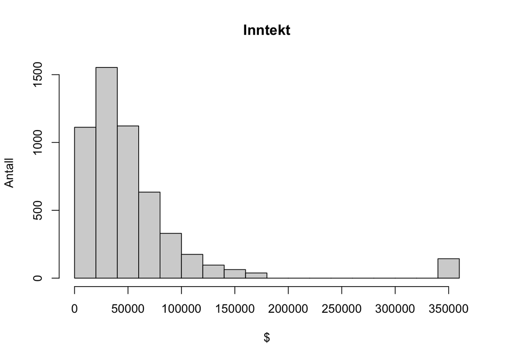

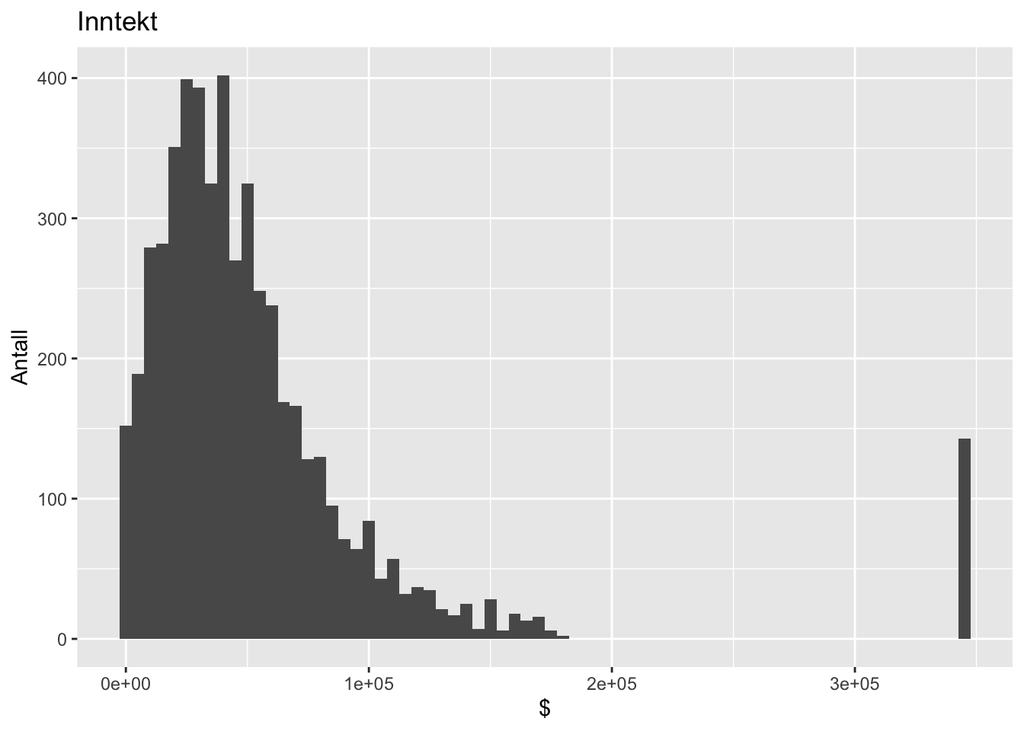

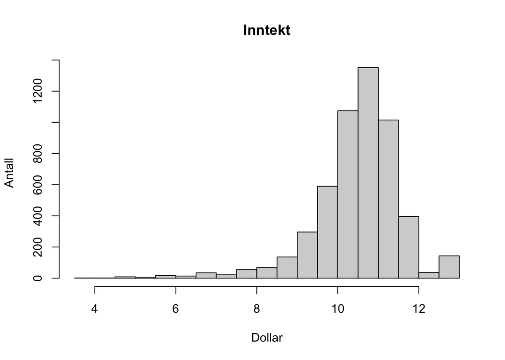

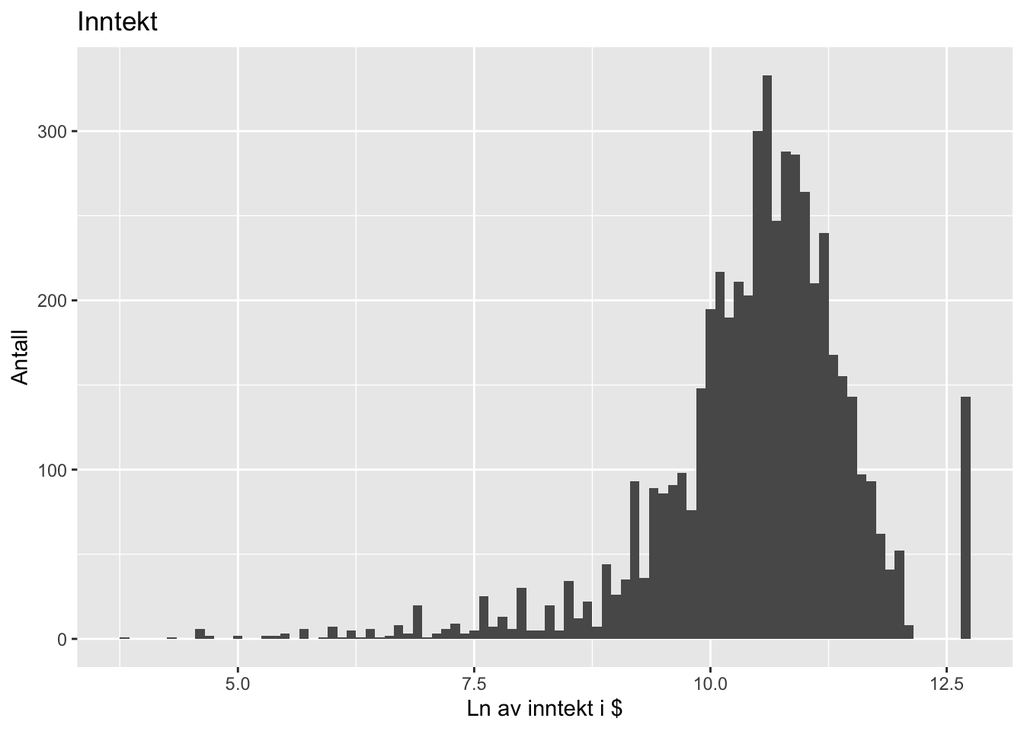

Logaritmen som har foretatt en transformasjon, noe som fører til at grafen har blitt tilnærmet normalfordelt med noen “outliers”.

### 3.3 To variabler analyse

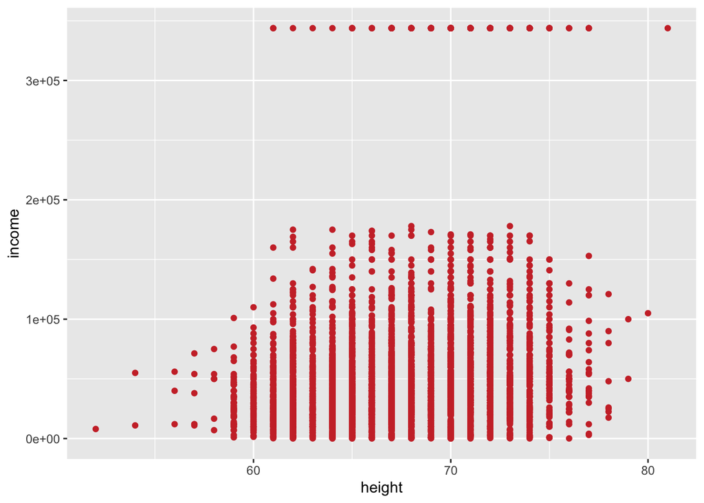

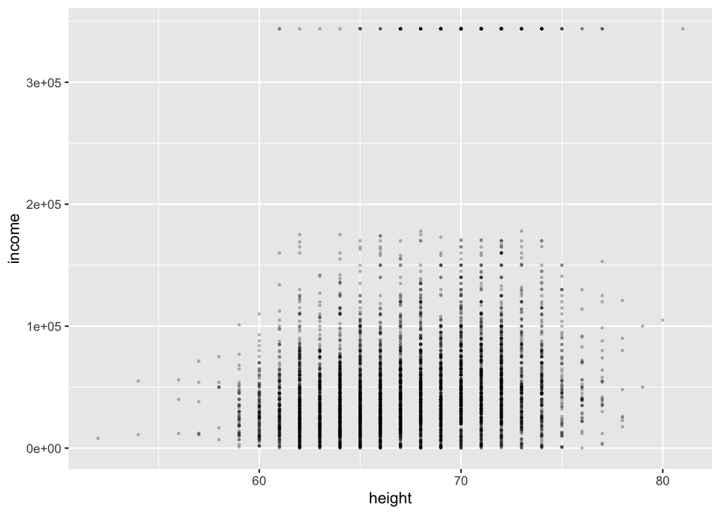

Her har vi et plot som viser til inntekten i henhold til høyden. Dette plottet viser en normalfordelt kurve.

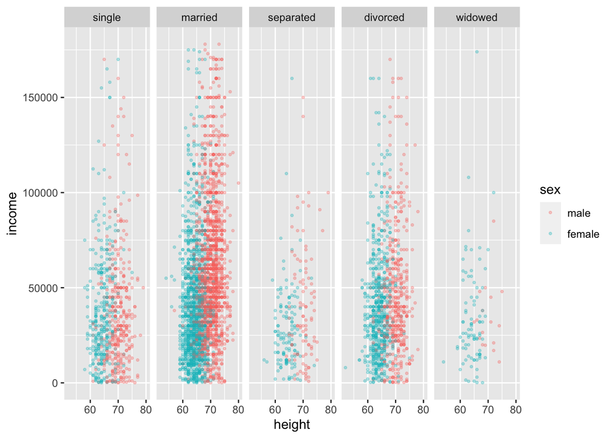

Her har vi plottet antall individer inn i sine sivilstatuser, for å se om det har en innvirkning på inntekten i forhold til høyde. Her kan vi se forskjellige korrelasjoner mellom sivilstatusene. separerte og enker tjener har den laveste lønnen i uansett betinget høyde. De som tjener mest er de som er gift ihenhold til plottet, samtidig som det er flest gifte i undersøkelsen.

Det plottet støtter ikke hypotesen om at individer tjener mer på grunn av høyde. Det viser til at de kan være andre faktorer som styrer lønn enn høyde.

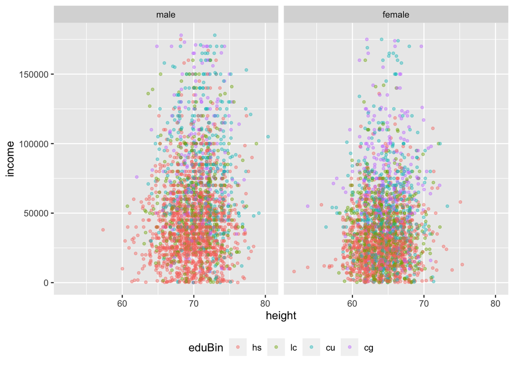

Det ble regnet et gjennomsnitt av de 2% høyeste inntekten (av personvernshensyn) og gjennomsnittet ble brukt til å erstatte alle verdiene i dette øverste siktet. Dette er sikkert personen som tjener langt over hva som er normalt å tjene.

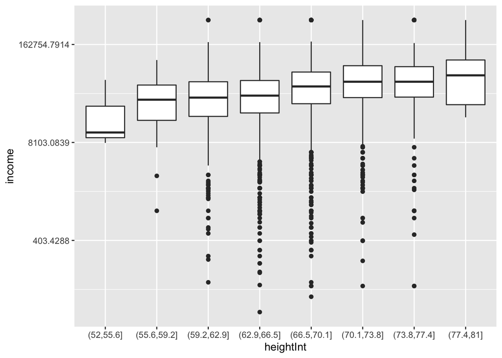

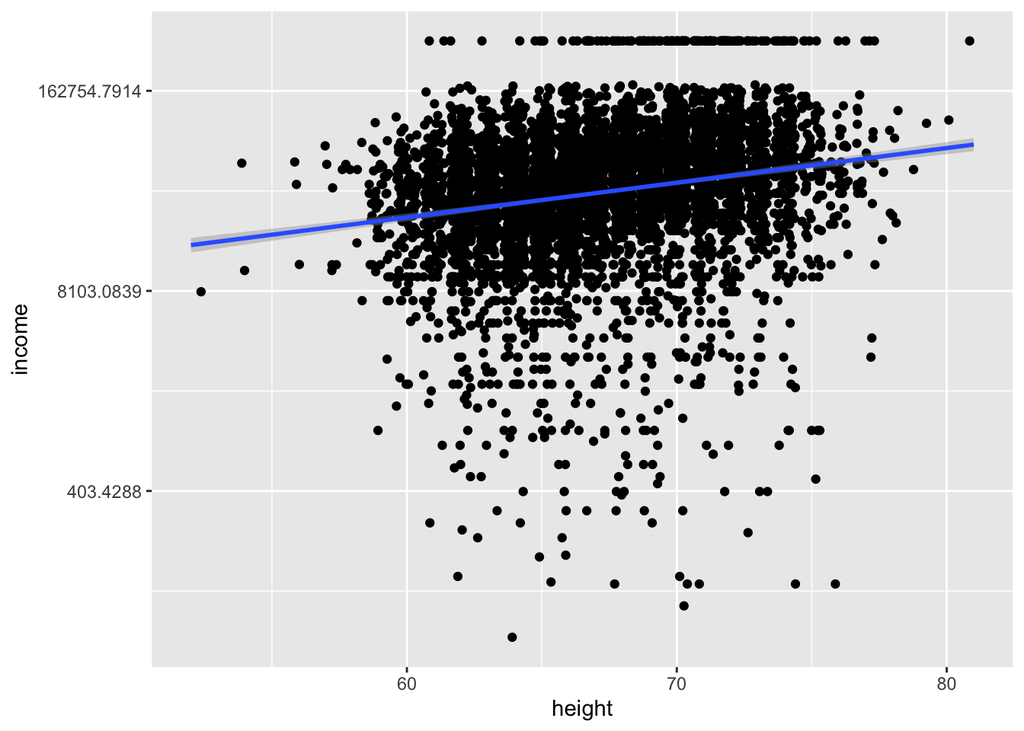

Her har det blitt laget en regresjon som tar for seg inntekt og høyde. Denne viser til hvor høy korrelasjonen er mellom inntekt og høyde. Vi kan se veldig mange som er under regresjons linjen, noe som kan tyde på at det er noen som tjener ekstremt godt. Dette påvirker modellen som gjør regresjonen mindre troverdig. Gapet mellom 8103$ og 162755$ er såpass stort at det blir tvedyig og vanskelig å tolke. Det er også outliers på alle høydene fra 60-80 inches.

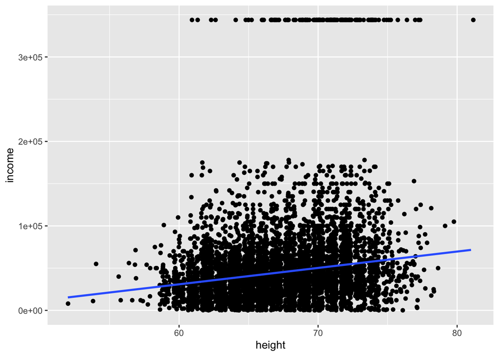

[output not shown]

```
##
## Call:
## lm(formula = income ~ height + marital, data = heights)
##
## Residuals:
##    Min     1Q Median     3Q    Max
## -87379 -29822 -10685  14269 318094
##
## Coefficients:
##                   Estimate Std. Error t value Pr(>|t|)
## (Intercept)      -165207.4    10720.3 -15.411  < 2e-16 ***
## height              2849.9      157.4  18.105  < 2e-16 ***
## maritalmarried     24594.4     1816.3  13.541  < 2e-16 ***
## maritalseparated   -3182.4     3222.4  -0.988    0.323
## maritaldivorced     8550.0     2098.8   4.074 4.68e-05 ***
## maritalwidowed      3730.2     4521.5   0.825    0.409
## ---
## Signif. codes:  0 '***' 0.001 '**' 0.01 '*' 0.05 '.' 0.1 ' ' 1
##
## Residual standard error: 53500 on 7000 degrees of freedom
## Multiple R-squared:  0.08431,    Adjusted R-squared:  0.08366
## F-statistic: 128.9 on 5 and 7000 DF,  p-value: < 2.2e-16
```

Når vi legger til variabelen om sivilstatus ser vi at for variabelen height er det liten endring. Vi får en liten nedgang, men av liten betydning. Det vi også kan se er at det er en forskjell i lønn avhengig av hvilken sivilstatus en har. Er en gift ser en at en kan forvente en høyere lønn på 24594 dollar, mens for de som er skilt kan forvente en høyere lønn på 8550 dollar. De to variablene er statistisk signifikante, mens variablene for separerte og enker ikke er det. Vi har brukt variabelen for single som utgangspunkt.

```
##
## Call:
## lm(formula = income ~ height + sex, data = heights)
##
## Residuals:
##    Min     1Q Median     3Q    Max
## -78750 -29095 -10585  14539 320185
##
## Coefficients:
##             Estimate Std. Error t value Pr(>|t|)
## (Intercept) -73841.6    15963.4  -4.626 3.80e-06 ***
## height        1816.6      227.3   7.991 1.55e-15 ***
## sexfemale   -13324.3     1856.7  -7.176 7.89e-13 ***
## ---
## Signif. codes:  0 '***' 0.001 '**' 0.01 '*' 0.05 '.' 0.1 ' ' 1
##
## Residual standard error: 54360 on 7003 degrees of freedom
## Multiple R-squared:  0.05439,    Adjusted R-squared:  0.05412
## F-statistic: 201.4 on 2 and 7003 DF,  p-value: < 2.2e-16
```

Når vi legger til variablene høyde og kjønn får vi en stor endring i betydningen av høyde. Den reduseres ned til 1817 dollar for hver ekstra inch. Det vi også får er at hvis man er kvinne kan en anta å få 13324 mindre i lønn enn en som er mann. Også her er alle variablene statistisk signifikante.

```
##
## Call:
## lm(formula = income ~ height + education, data = heights)
##
## Residuals:
##     Min      1Q  Median      3Q     Max
## -120461  -27357   -6852   14954  342759
##
## Coefficients:
##              Estimate Std. Error t value Pr(>|t|)
## (Intercept) -245262.3    10197.2  -24.05   <2e-16 ***
## height         2654.5      147.5   17.99   <2e-16 ***
## education      8199.2      231.6   35.40   <2e-16 ***
## ---
## Signif. codes:  0 '***' 0.001 '**' 0.01 '*' 0.05 '.' 0.1 ' ' 1
##
## Residual standard error: 50260 on 6993 degrees of freedom
##   (10 observations deleted due to missingness)
## Multiple R-squared:  0.1921, Adjusted R-squared:  0.1919
## F-statistic: 831.4 on 2 and 6993 DF,  p-value: < 2.2e-16
```

Med variablene høyde og utdanning ser vi at utdanning har større betydning enn høyde. Det er noe vi intuitivt kan tenke oss at er korrekt. Begge har positiv påvirkning på lønnen og er statistisk signifikante.

```
##
## Call:
## lm(formula = income ~ height + marital + sex + education + weight +
##     afqt, data = heights)
##
## Residuals:
##     Min      1Q  Median      3Q     Max
## -117422  -25051   -5166   14781  327375
##
## Coefficients:
##                   Estimate Std. Error t value Pr(>|t|)
## (Intercept)      -64924.83   15237.30  -4.261 2.06e-05 ***
## height              292.56     227.79   1.284   0.1991
## maritalmarried    14131.01    1754.13   8.056 9.28e-16 ***
## maritalseparated   3354.59    3055.64   1.098   0.2723
## maritaldivorced    5577.09    1990.84   2.801   0.0051 **
## maritalwidowed    10362.61    4285.63   2.418   0.0156 *
## sexfemale        -24850.40    1744.56 -14.244  < 2e-16 ***
## education          5942.10     289.16  20.549  < 2e-16 ***
## weight              -22.51      15.41  -1.460   0.1442
## afqt                390.29      26.51  14.720  < 2e-16 ***
## ---
## Signif. codes:  0 '***' 0.001 '**' 0.01 '*' 0.05 '.' 0.1 ' ' 1
##
## Residual standard error: 49100 on 6635 degrees of freedom
##   (361 observations deleted due to missingness)
## Multiple R-squared:  0.2554, Adjusted R-squared:  0.2544
## F-statistic: 252.8 on 9 and 6635 DF,  p-value: < 2.2e-16
```

Dersom vi legger til alle variablene i en modell kan vi se at tre av variablene ikke er statistisk signifikante, en av dem er variabelen “height”. De resterende variablene er statistisk signifikante.

Vi viser med et eksempel hvordan modellen fungerer, og bruker gjennomsnittet til variablene, samt at vi bruker en gift mann.

```r
-64924.83 + 292.56*67.1 + 14131.01 + 5942.1*13.22 - 22.51*188.3 + 390.29*41.21
```

```
## [1] 59236.74
```

Inntekten til en gjennomsnittlig gift mann vil da være 59236.74 dollar. Den inntekten er godt over hva gjennomsnittslønnen i datasettet tilsier.

```r
-64924.83 + 14131.01 + 5942.1*13.22 + 390.29*41.21
```

```
## [1] 43844.59
```

Tar vi derimot bort de variablene som ikke er statistisk signifikante får vi en inntekt som er nærmere det gjennomsnittet som kom fra datasettet, og vi får en lønn på gjennomsnittlig gift mann på 43844.59 dollar.

## 4. Konklusjon

Utfra vår siste modell får vi at variabelen “height” ikke er signifikant, noe som forteller oss at den variabelen i det datasettet ikke har påvirkning på inntekten. Det vi legger merke til er at variabelen for hvilket kjønn man er og at den er statistisk signifikant. I modellen kommer det frem at om en er kvinne får en lavere lønn enn menn, og siden det er fysiske forskjeller mellom menn og kvinner kan en dermed ikke utelukke helt at høyde har betydning på inntekt.

## Referanseliste

Case, Anne, og Christina Paxson. 2006. «Stature and Status: Height, Ability, and Labor Market Outcomes». w12466. Cambridge, MA: National Bureau of Economic Research. https://doi.org/10.3386/w12466.

Cinnirella, Francesco, og Joachim K. Winter. 2009. «Size Matters! Body Height and Labor Market Discrimination: A Cross-European Analysis». SSRN Scholarly Paper ID 1443091. Rochester, NY: Social Science Research Network.

«Height, Income, and Inequality | Iris». u.å. https://www.iris.xyz/research/height-income-and-inequality/.

Lundborg, Petter, Paul Nystedt, og Dan-Olof Rooth. 2014. «Height and Earnings: The Role of Cognitive and Noncognitive Skills». *The Journal of Human Resources* 49 (1): 141–66.

Malt, Ulrik. 2019. «kognitive funksjoner». *Store norske leksikon*, desember.

Schick, Andreas, og Richard H. Steckel. 2015. «Height, Human Capital, and Earnings: The Contributions of Cognitive and Noncognitive Ability». *Journal of Human Capital* 9 (1): 94–115. https://doi.org/10.1086/679675.